# eu-circle_case-study-1

Rasmus Benestad

May 2, 2016

## Extreme Dryness and forest fires on electricity and transport networks

Simultaneous forest fires ignite in the Bouche du Rhone department near Aix en Porvence, and in the Alpes Maritimes Department, at the French/Italian frontier, near a highway (A8) used by thousands of tourists. Due to the important smoke production, visibility is strongly reduced so that highway has to be closed, leading to an important traffic on the secondary road networks. The crossing of the frontier by car being completely impossible, traffic between France and Italy has to be diverted. Tourists are confined on highway rest areas. People, blocked on the roads, have difficulties to breathe because of the smoke and leave their cars, scattering into the nature. Additional accidents are caused because of the panic of people. Due to aerial firefighting, electricity lines have to be cut. Due to the fire smoke, aerial traffic in Nice airport has to be stopped. Numerous dwellings are without electricity and of course without telephones. Other emergency operations are disturbed because of the large delay of alert, major dispersion of means, decrease of available means.

**Precipitation**

*Station data*

Represent the station data with lower-case $x$

```r
library(esd)
```

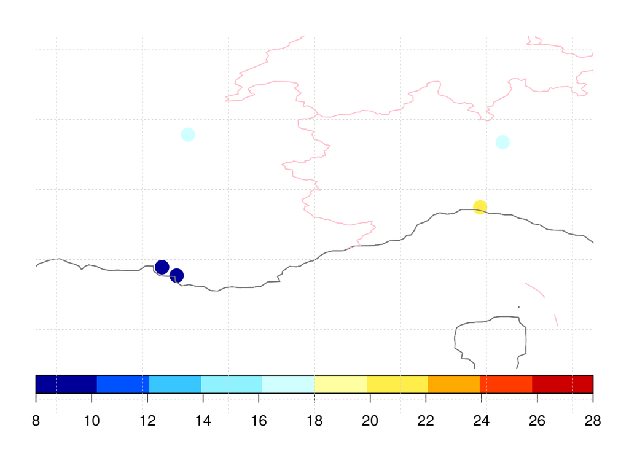

```r
if (!file.exists('eu-circle_case-study-1_precio.rda')) {
  ss <- select.station(param='precip',lon=c(5,10),lat=c(42,45),nmin=50,src=c('ecad','ghcnd'))
  x <- station(ss)
  x <- subset(x,is=list(alt=-400))
  save(file='eu-circle_case-study-1_precio.rda',x)
} else load('eu-circle_case-study-1_precio.rda')
## Only keep the ECAD data
x <- subset(x,is=is.element(src(x),'ECAD'))
map(x,FUN='q95',new=TRUE)
```

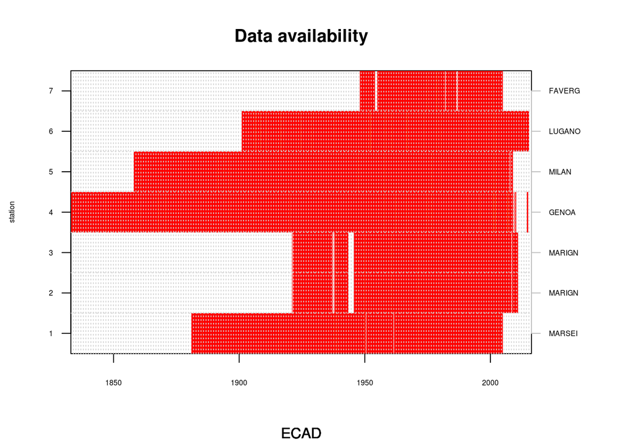

```r
diagnose(x)
```

The raw daily precipitation data. The colour of the curves correspond to the colour marker of the location. There have been some instances with very large precipitation amounts in the past.

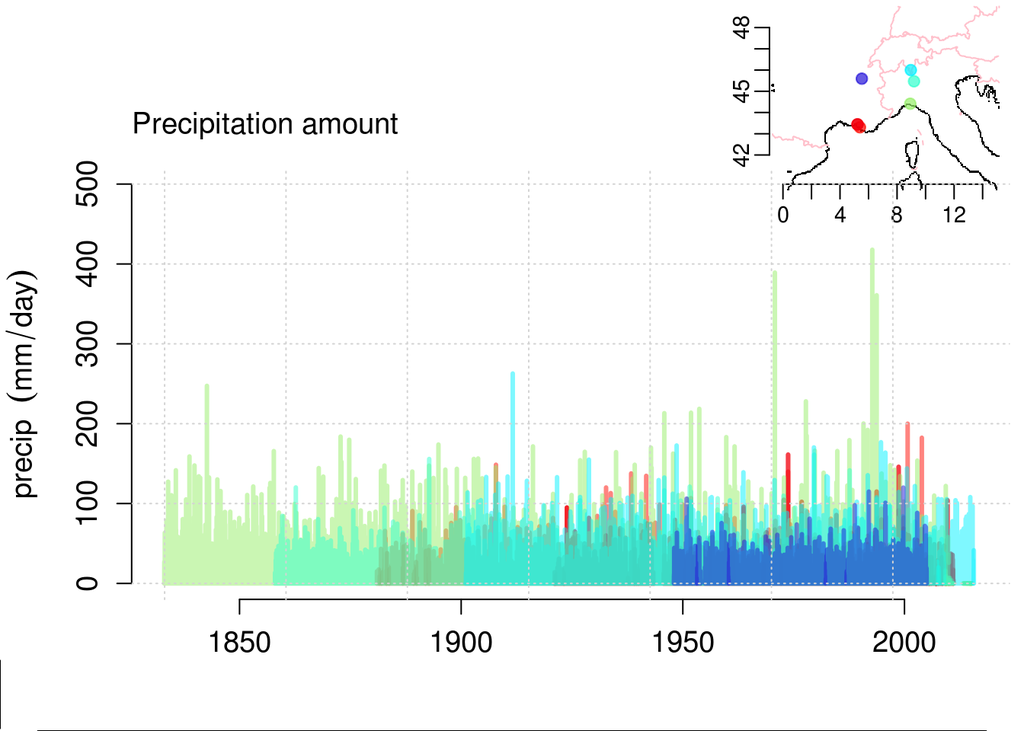

```r
plot(x,new=FALSE)
grid()
```

Examine the trend in the wet-day mean precipitation $\mu$

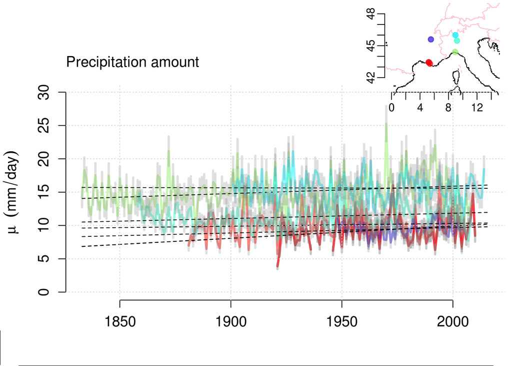

```r
mu <- annual(x,'wetmean',nmin=250)
wq95 <- function(x) {x <- x[is.finite(x)]; x <- x[x >= 1]; wq95 <- quantile(x,probs=0.95); wq95}
q95 <- annual(x,'wq95')
plot(mu,new=FALSE)
for (i in 1:dim(mu)[2]) lines(trend(subset(mu,is=i)),lty=2)
grid()
```

There appears to be a slight increasing trend in $\mu$ for most stations, according to a linear regression analysis against time. There are also pronounced year-to-year variations in $\mu$ with high “spikes” in some years.

Need to check to see if $\mu$ is correlated with number of rainy days, e.g. can be high due to smaller samples and higher sampling fluctuations:

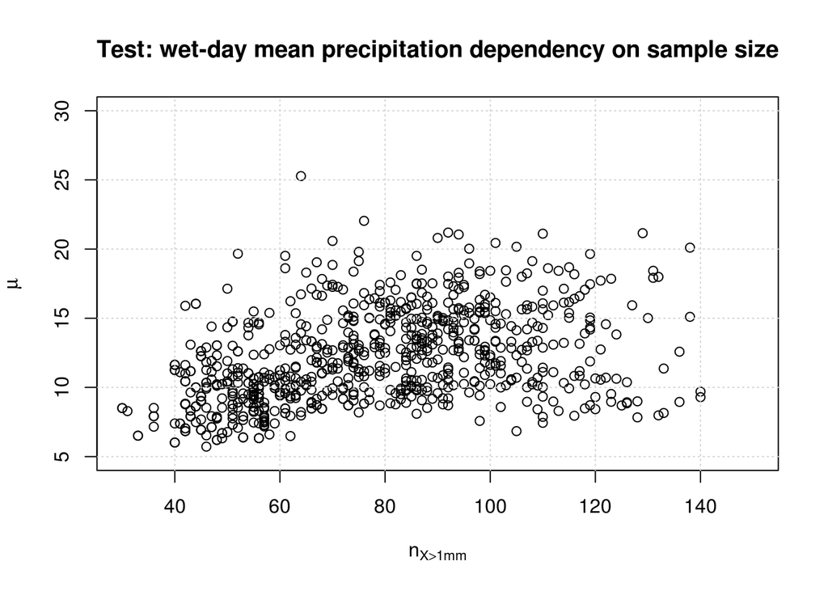

```r
x1 <- zoo(subset(annual(x,'count',threshold=1),is=1))
y1 <- zoo(subset(mu,is=1))
plot(x1,y1,xlab=expression(n[X>1*mm]),ylab=expression(mu),xlim=c(30,150),ylim=c(5,30),
     main='Test: wet-day mean precipitation dependency on sample size')
for (i in 2:dim(mu)[2]) {
  x1 <- zoo(subset(annual(x,'count',threshold=1),is=i))
  y1 <- zoo(subset(mu,is=i))
  points(x1,y1)
}
grid()
```

There is no indication suggesting that high value of annual $\mu$ is connected with a low number of rain events.

For many purposes, it may be useful to assume that the daily precipitation amount is approximately exponentially distributed for the days when it rains and that the probability of the precipitation exceedin a threshold value $x_0$ can be estimated according to $Pr(X>x_0) = f_w e^{-x_0/\mu}$ where $f_w$ is the wet-day frequency. Below is a test for whether the amount is close to exponential for a wet day.

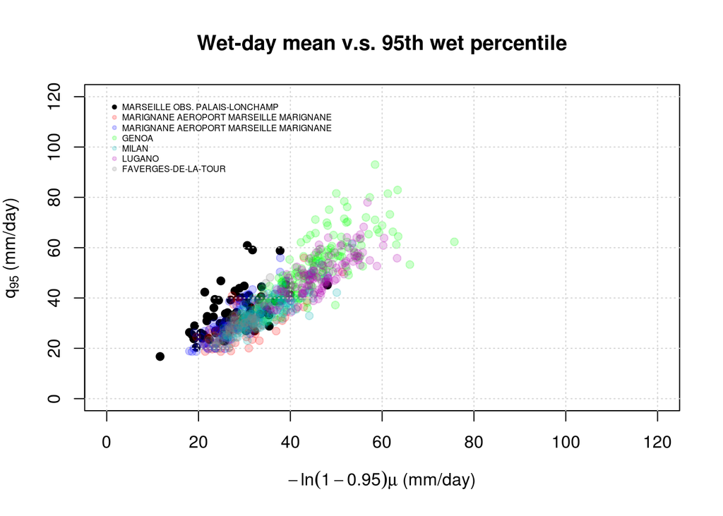

```r
## check the relationship between wet-day 95-percentile and wet-day mean
plot(-log(0.05)*zoo(mu[,2]),zoo(q95[,1]),pch=19,xlim=c(0,120),ylim=c(0,120),
     main='Wet-day mean v.s. 95th wet percentile',
     xlab=expression(paste(-ln(1-0.95)*mu,' (mm/day)')), ylab=expression(paste(q[95],' (mm/day)')))
points(-log(0.05)*zoo(mu[,1]),zoo(q95[,2]),pch=19,col=rgb(1,0,0,0.2))
points(-log(0.05)*zoo(mu[,3]),zoo(q95[,3]),pch=19,col=rgb(0,0,1,0.2))
points(-log(0.05)*zoo(mu[,4]),zoo(q95[,4]),pch=19,col=rgb(0,1,0,0.2))
points(-log(0.05)*zoo(mu[,5]),zoo(q95[,5]),pch=19,col=rgb(0,0.7,0.7,0.2))
points(-log(0.05)*zoo(mu[,6]),zoo(q95[,6]),pch=19,col=rgb(0.7,0,0.7,0.2))
points(-log(0.05)*zoo(mu[,7]),zoo(q95[,7]),pch=19,col=rgb(0.5,0.5,0.5,0.2))
grid()
legend(0,120,loc(mu),pch=19,col=c('black',rgb(1,0,0,0.2),rgb(0,0,1,0.2),rgb(0,1,0,0.2),rgb(0,0.7,0.7,0.2),rgb(0.7,0,0.7,0.2),rgb(0.5,0.5,0.5,0.2)),bty='n',cex=0.5)
```

The scatter plot suggests that the points are mainly clustered around the diagonal and hence the 24-hr precipitation amoun is approximately exponentially distributed. The Marseille data seem to be less similar to the exponential distribution than the other sites.

We also need to examine the trend in the wet-day frequency:

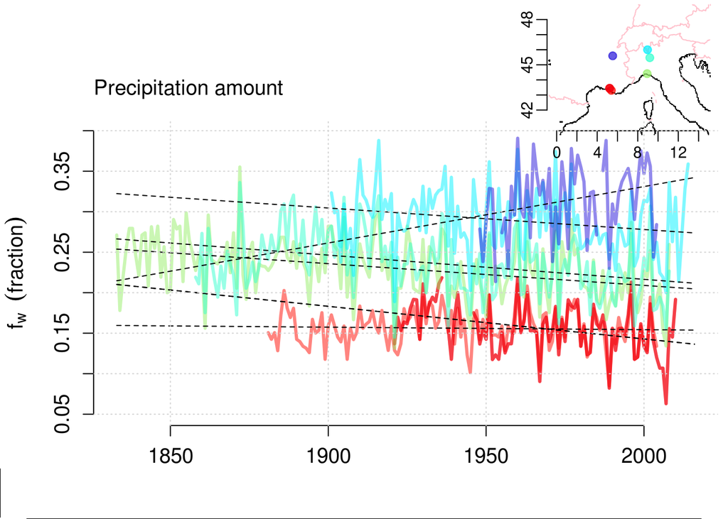

```r
fw <- annual(x,'wetfreq',nmin=250)
plot(fw,new=FALSE)
for (i in 1:dim(fw)[2]) lines(trend(subset(fw,is=i)),lty=2)
grid()
```

The rain gauge data suggests decreasing trends in $f_w$ for most locations, except for the highest station (360 m a.s.l.) further inland (Faverges-de-la-Tour) and with a short record.

Estimate the evolution in the probability for heavy precipitation: $Pr(X > x) = f_w e^{-x_0/\mu}$.

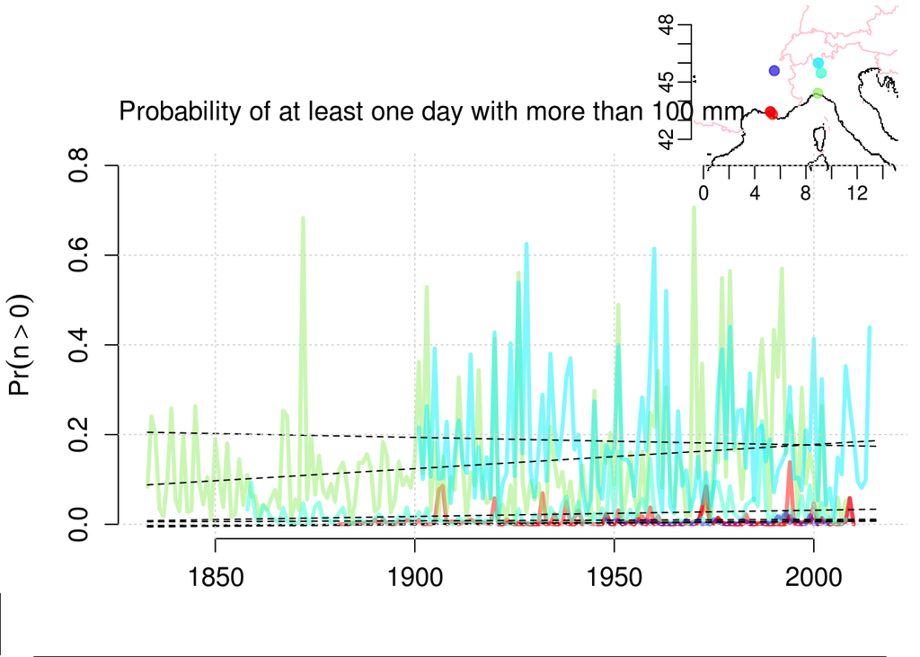

```r
x0 <- 100 #mm
Pr <- zoo(1-pbinom(0,size=365,prob=coredata(fw)*exp(-x0/coredata(mu))),order.by=year(fw))
class(Pr) <- class(mu)
Pr <- attrcp(mu,Pr)
attr(Pr,'variable') <- 'Pr'
attr(Pr,'unit') <- 'probability'
attr(Pr,'longname') <- paste('probability of at least one day with more than',x0,'mm')
plot(Pr,ylab=expression(Pr(n>0)),xlab='',new=FALSE,errorbar=FALSE,
          main=paste('Probability of at least one day with more than',x0,'mm'))
for (i in 1:dim(Pr)[2]) lines(trend(subset(Pr,is=i)),lty=2)
grid()
```

The results indicate large annual variations in the probability of extreme precipitation ($X > 100mm$), suggesting a high sensitivity to both $\mu$ and $f_w$. This sensitivity is also seen in the different estimates for different locations, even if the difference between the mean $\mu$ is not as dramatic.

One relevant parameter is the duration of dry and wet spells (number of dry/wet consecutive days). The grapghic below shows the length of dry (red) and wet (blue) intervals (dry are plotted with negative sign for clarity).

```r
z <- subset(x,it=c(1900,2016),is=1)
ncd <- spell(z,threshold=1)
```

```
## [1] "Warning:  4235 missing values ( 10  %) filled by interpolation"
```

```r
plot(ncd)
```

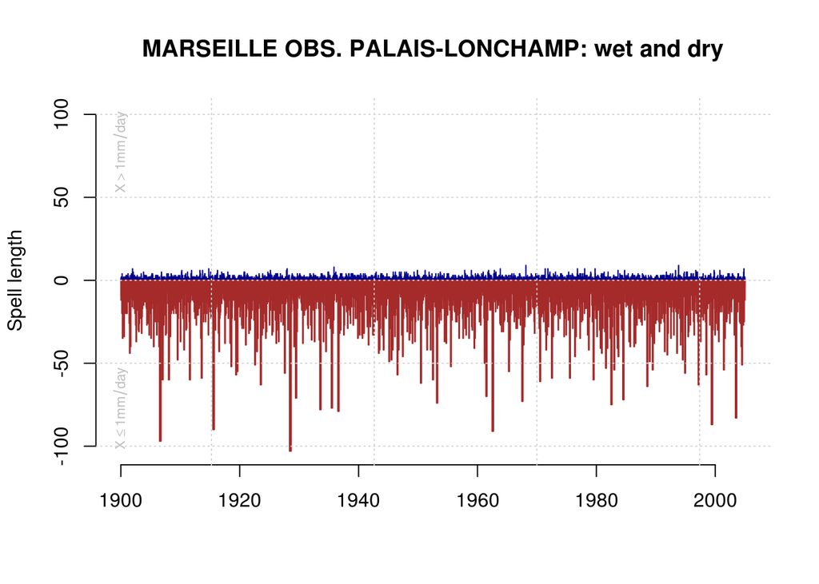

```r
grid()
```

The dry runs usually last longer than the wet runs. some of the longest dry spells have lasted for ~100 days, but it has rarely rained more than 5 days in a row. One question is whether the dry/wet spell statistics can be considered to be a result of random/stochastic processes, or if they contain more structure.

If there is only a fixed probability for wet/dry day that detemines the outcome, then we can use the geometric distribution to represent the statistics of the wet/dry spells: https://en.wikipedia.org/wiki/Geometric_distribution. The question then is how closely the duration of wet/dry spells follow the geometric distribution. The histogram below compares the data to the pdfs for the geometric distribution and suggest a good match.

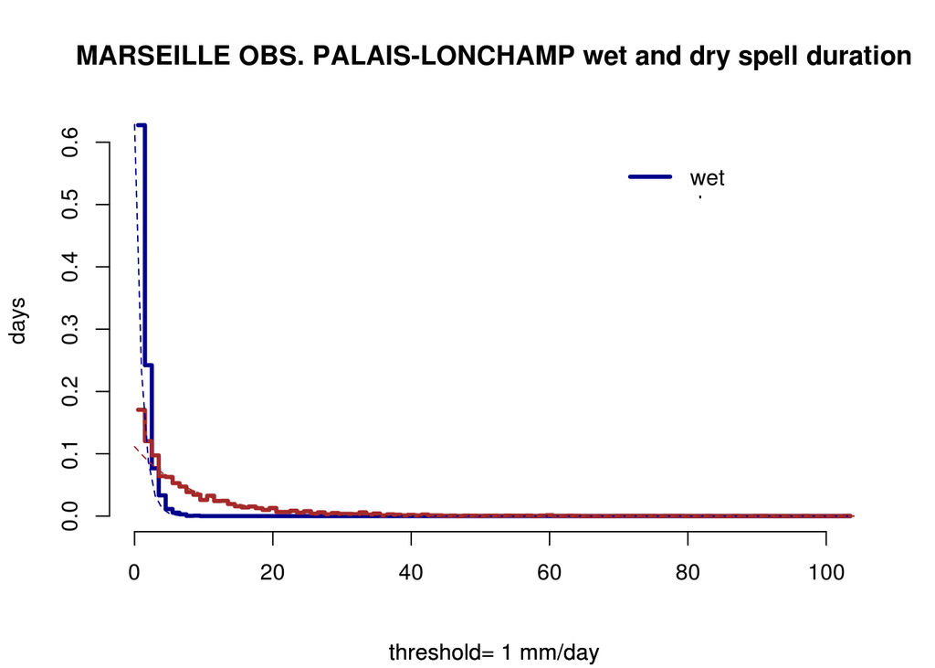

```r
hist(ncd)
```

The mean value if the parameter that describes the shape of the geometric distribution. The comparison suggests that it does not give a bad representation of the observed charactereistics.

The second question is then: Are there any trends in the annual mean durations?

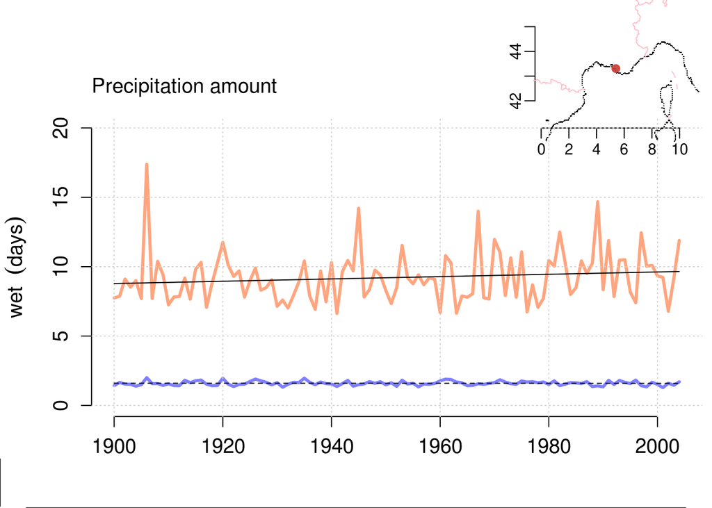

```r
amncd <- annual(ncd)
plot(amncd,col=c(rgb(0,0,1),rgb(1,0.3,0)),new=FALSE)
grid()
lines(trend(subset(amncd,is=1)),lty=2)
mcdd <- trend(subset(amncd,is=2))
lines(mcdd,lty=1)
```

```r
print(attr(mcdd,'coefficients'))
```

```
##                 Estimate  Std. Error    t value  Pr(>|t|)
## (Intercept) -7.112431978 11.52234617 -0.6172729 0.5384170
## t            0.008366542  0.00590213  1.4175462 0.1593413
```

There is a slight increasing trend in the annual mean duration of dry spells, which also has a consequence for the probability of long-lasting meteorological droughts.

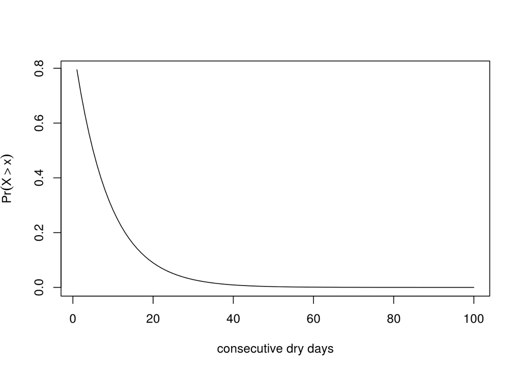

```r
plot(1-pgeom(1:100,1/mean(mcdd)),type='l',xlab='consecutive dry days',ylab=expression(Pr(X > x)))
```

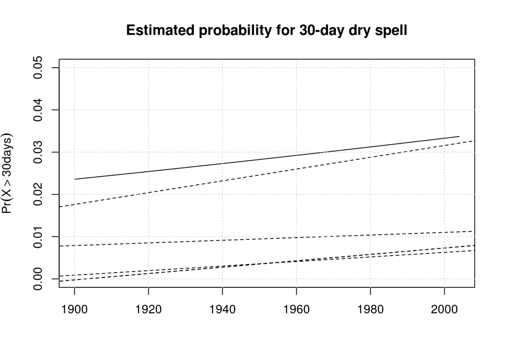

```r
plot(index(mcdd),1-pgeom(30, 1/mcdd),type='l',xlab='',ylab=expression(Pr(X > 30*days)),
     main='Estimated probability for 30-day dry spell',ylim=c(0,0.05))
for (i in 1:dim(Pr)[2]) lines(trend(subset(Pr,is=i)),lty=2)
grid()
```

*Gridded precipitation*

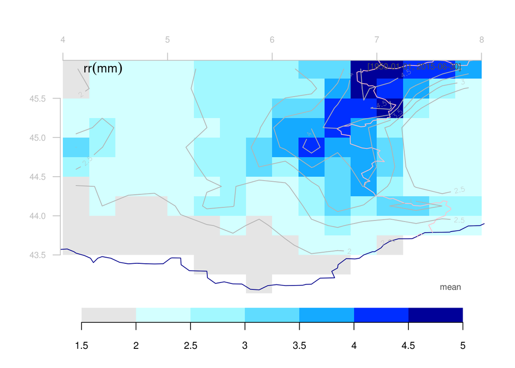

```r
X <- retrieve('data.ECAD/rr_0.25deg_reg_v12.0.nc',lon=c(4,8),lat=c(43,46))
map(X,new=FALSE)
```

The mean dry spell duration

```
## [1] "Warning:  1 missing values ( 0  %) filled by interpolation"
## [1] "Warning:  1 missing values ( 0  %) filled by interpolation"
## [1] "Warning:  1 missing values ( 0  %) filled by interpolation"
## [1] "Warning:  1 missing values ( 0  %) filled by interpolation"
## [1] "Warning:  1 missing values ( 0  %) filled by interpolation"
```

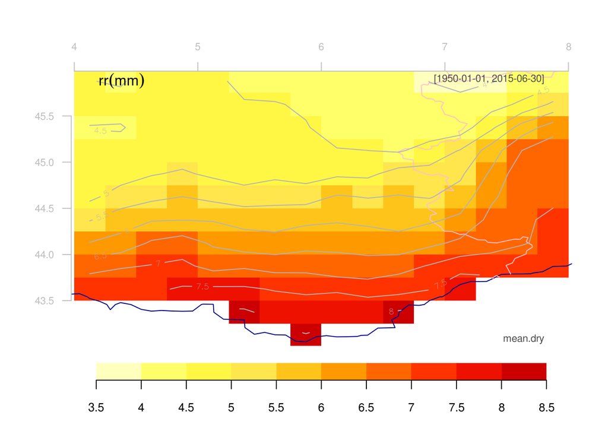

```r
mean.dry <- function(x,na.rm=TRUE) mean(subset(spell(x,threshold=1),is=2),na.rm=na.rm)
map(X,FUN='mean.dry',new=FALSE,colbar=list(pal='warm'))
```

```
## [1] "Warning:  1 missing values ( 0  %) filled by interpolation"
## [1] "Warning:  1 missing values ( 0  %) filled by interpolation"
## [1] "Warning:  1 missing values ( 0  %) filled by interpolation"
## [1] "Warning:  1 missing values ( 0  %) filled by interpolation"
## [1] "Warning:  1 missing values ( 0  %) filled by interpolation"
```

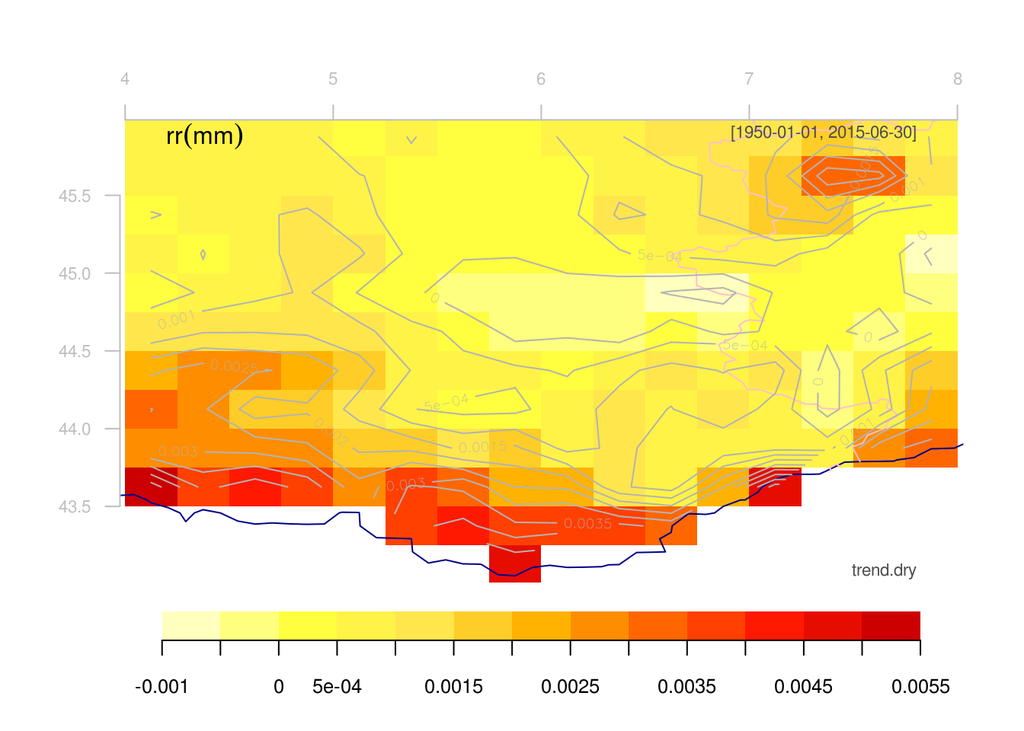

```r
trend.dry <- function(x,na.rm=TRUE) trend.coef(subset(spell(x,threshold=1),is=2))
map(X,FUN='trend.dry',new=FALSE,colbar=list(pal='warm'))
```